# Forest Fires in Brazil

#Introduction Forest fires are a serious problem for the preservation of the Tropical Forests. Understanding the frequency of forest fires in a time series can help prevent them. Brazil has the largest rainforest on the planet, the Amazon rainforest. This report analyses the frequency of forest fires by the state in which the fire occurred as well as the time or season.

```r
fires <- read_csv(here::here("data-raw", "amazon.csv"))
head(fires)
```

```
## # A tibble: 6 x 5
##    year state month   number date
##   <dbl> <chr> <chr>    <dbl> <date>
## 1  1998 Acre  Janeiro      0 1998-01-01
## 2  1999 Acre  Janeiro      0 1999-01-01
## 3  2000 Acre  Janeiro      0 2000-01-01
## 4  2001 Acre  Janeiro      0 2001-01-01
## 5  2002 Acre  Janeiro      0 2002-01-01
## 6  2003 Acre  Janeiro     10 2003-01-01
```

##Descriptive Statistics We begin by visualising the data.

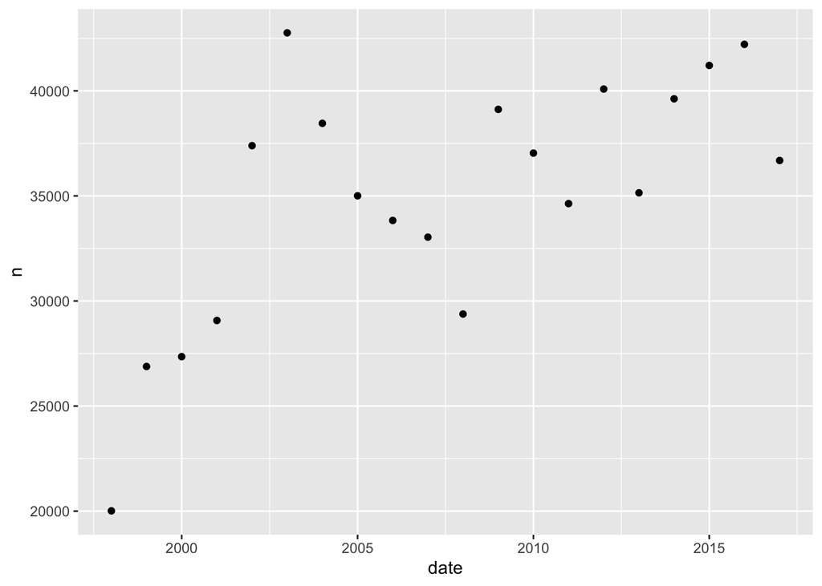

```r
fires %>%
  count(date, wt = number) %>%
  ggplot(aes(x = date, y = n)) +
  geom_point()
```

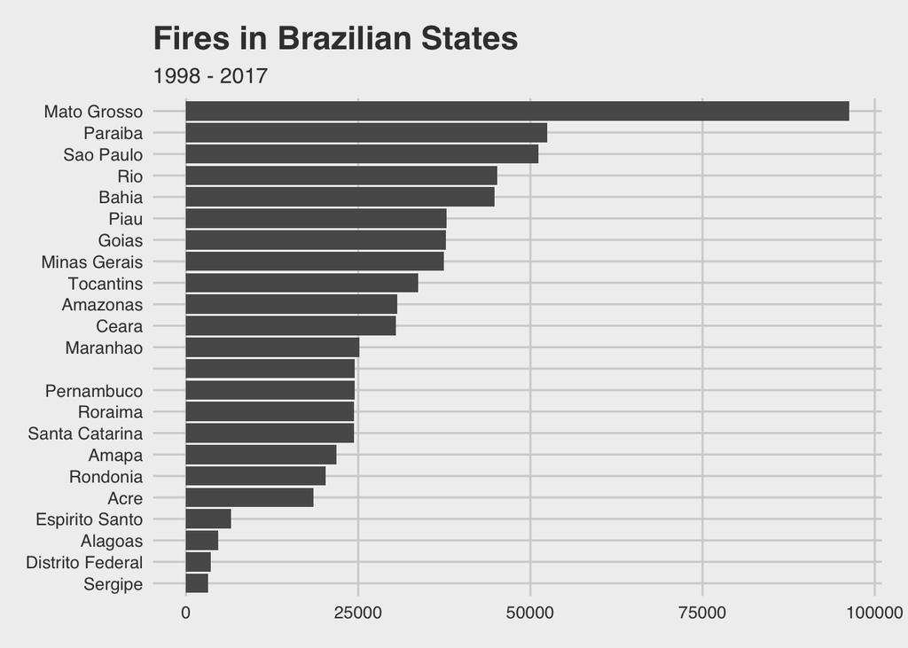

```r
fires %>%
  as_tibble() %>%
  group_by(state) %>%
  summarise(fires = sum(number)) %>%
  mutate(state=forcats::fct_reorder(state,fires)) %>%
  ggplot(aes(x = state, y = fires))+
  geom_bar(stat = "identity")+
  coord_flip()+
  ggthemes :: theme_fivethirtyeight() +
  ggtitle("Fires in Brazilian States", subtitle = "1998 - 2017")
```

It should be noted that one of the states is blank on the plot. This needs to be investigated in the data cleaning process.

From the plot of date against the number of forest fires reported it can be seen that forest fires were the most prevalent during 2003 with over 42500 counts of forest fires. 2016 follows close by with a count slightly below 42500 fires. Over the years, the prevalence of forest fires appear to increase closer to 40000 forest fires.

The plot of state against the number of forest fires reported demonstrates the outstanding prevalence of forest fires in Mato Grosso compared to the other states. Whether this is an outlier or error due to measurement or data compilation should be investigated during the data cleaning process.

#Data Cleaning

##The Problematic Month It should be noted that the month terms in the data set are in Portuguese and as such are not passable to standard date conversion functions. These must be translated in order to connect accurate dates to the data. There is an issue with this however, as the term that describes March uses non-standard characters and cannot be directly converted.

First we need to access the term and store it in an object; this will allow us to reference it directly as it is not possible to type it into quotes. This object is obtained by filtering the data down to only rows that contain some non-alphabetic characters and then taking the first term. It should be noted that there is only one such problem term and as such, doing this is not an issue.

```r
problem_term <- fires %>%
  filter(stringr::str_detect(month, "[^a-zA-Z]")) %>%
  slice(1) %>%
  pull(month)
```

Now that we have an explicit definition of the problem term, it is possible to encode the direct conversions. The date is also created based on these months, using the first day of the month as a day reference.

```r
fires_date <- fires %>%
  mutate(month_clean = case_when(
    month == "Abril"        ~ "April",
    month == "Agosto"       ~ "August",
    month == "Dezembro"     ~ "December",
    month == "Fevereiro"    ~ "February",
    month == "Janeiro"      ~ "January",
    month == "Julho"        ~ "July",
    month == "Junho"        ~ "June",
    month == "Maio"         ~ "May",
    month == problem_term     ~  "March",
    month == "Novembro"     ~ "November",
    month == "Outubro"      ~ "October",
    month == "Setembro"     ~ "September",
    TRUE                    ~ NA_character_
  ),
  day = 1) %>%
  mutate(date_month = lubridate::ymd(glue::glue("{year}-{month_clean}-{day}"))) %>%
  mutate(date_index = yearmonth(date_month))

head(fires_date)
```

```
## # A tibble: 6 x 9
##    year state month number date       month_clean   day date_month
##   <dbl> <chr> <chr>  <dbl> <date>     <chr>       <dbl> <date>
## 1  1998 Acre  Jane…      0 1998-01-01 January         1 1998-01-01
## 2  1999 Acre  Jane…      0 1999-01-01 January         1 1999-01-01
## 3  2000 Acre  Jane…      0 2000-01-01 January         1 2000-01-01
## 4  2001 Acre  Jane…      0 2001-01-01 January         1 2001-01-01
## 5  2002 Acre  Jane…      0 2002-01-01 January         1 2002-01-01
## 6  2003 Acre  Jane…     10 2003-01-01 January         1 2003-01-01
## # … with 1 more variable: date_index <mth>
```

##Creating a time aware data frame As this is monthly data, we want to explicitly encode this in the data set using the yearmonth function to create an index. A key is given as there is data repeated accross states.

Exploring the data has revealed some states have duplicated data. The duplicated counts for specific states - Mato Grosso, Rio and Paraiba - are filtered using the following code.

```r
fires_clean <-
  fires_date %>%
  filter(!(state %in% c("Mato Grosso", "Rio", "Paraiba"))) %>%
  filter(duplicated(.) == FALSE) %>%
  select(-c(month, date, day, date_month)) %>%
  rename(date = date_index, month = month_clean, fires = number) %>%
  mutate(state = ifelse(str_detect(state, "Par\xe1"), "Para", state)) %>%
  as_tsibble(index = date, key = state)


fires_clean_all <-
  fires_date %>%
  filter(!(state %in% c("Mato Grosso", "Rio", "Paraiba"))) %>%
  filter(duplicated(.) == FALSE) %>%
  group_by(date_index) %>%
  summarise(fires = sum(number)) %>%
  as_tsibble(index = date_index) %>%
  rename(date = date_index)

fires_all <- fires_clean_all

head(fires_clean)
```

```
## # A tsibble: 6 x 5 [1M]
## # Key:       state [1]
##    year state fires month        date
##   <dbl> <chr> <dbl> <chr>       <mth>
## 1  1998 Acre      0 January  1998 Jan
## 2  1998 Acre      0 February 1998 Feb
## 3  1998 Acre      0 March    1998 Mar
## 4  1998 Acre      0 April    1998 Apr
## 5  1998 Acre      0 May      1998 May
## 6  1998 Acre      3 June     1998 Jun
```

```r
head(fires_all)
```

```
## # A tsibble: 6 x 2 [1M]
##       date fires
##      <mth> <dbl>
## 1 1998 Jan     0
## 2 1998 Feb     0
## 3 1998 Mar     0
## 4 1998 Apr     0
## 5 1998 May     0
## 6 1998 Jun  1225
```

We can also check the problematic state has been cleaned up:

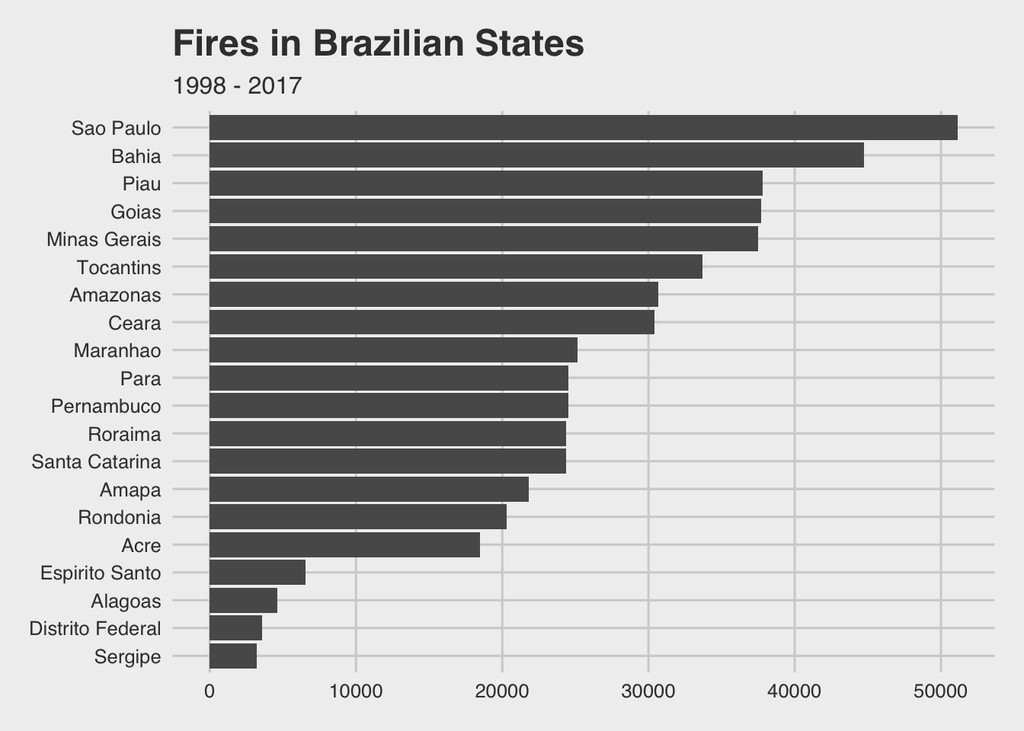

```r
fires <- fires_clean

fires %>%
  as_tibble() %>%
  group_by(state) %>%
  summarise(fires = sum(fires)) %>%
  mutate(state=forcats::fct_reorder(state,fires)) %>%
  ggplot(aes(x = state, y = fires))+
  geom_bar(stat = "identity")+
  coord_flip()+
  ggthemes :: theme_fivethirtyeight() +
  ggtitle("Fires in Brazilian States", subtitle = "1998 - 2017")
```

#Data Analysis

##Decomposition of Amazon data The aggregate amazon fire data will be decomposed in order to analyse the error terms of the time series model.

```
## Model not specified, defaulting to automatic modelling of the `fires` variable. Override this using the model formula.
```

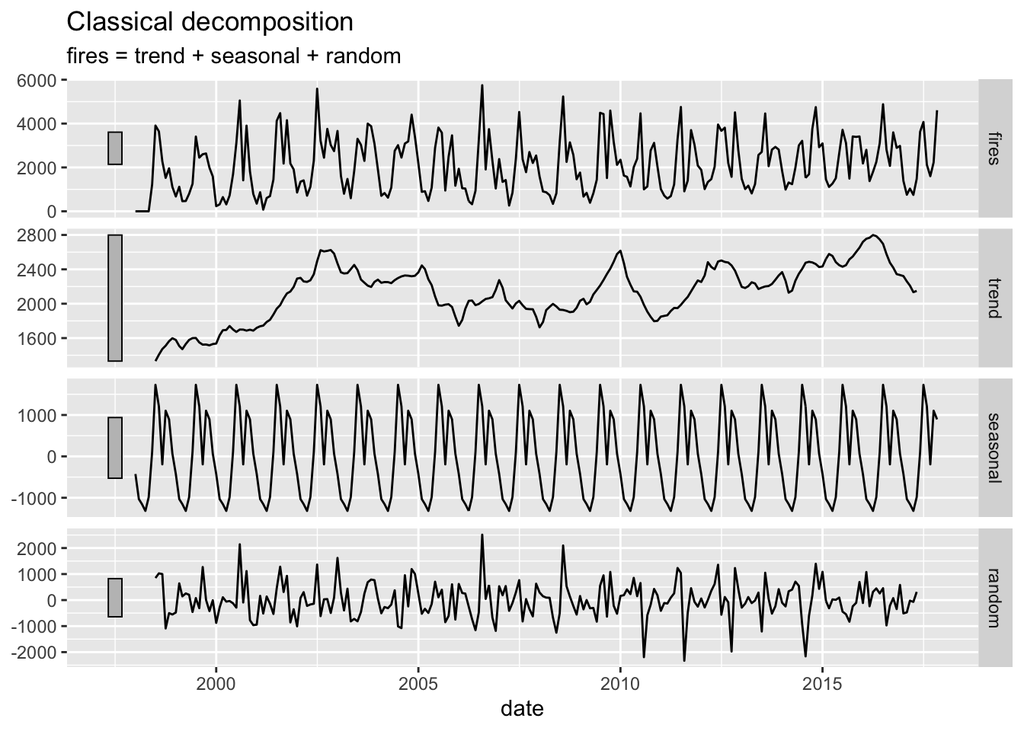

```r
fires_all %>%
  classical_decomposition() %>%
  autoplot()
```

It can be seen that there is a strong seasonal component with two consistent peaks. The overall trend shows an overall increase, though it is not constantly increasing.

###Deseasoning We begin by deseasoning the data. A year comprises of four seasons and each season is approximately three months in length. Thus to summarise the data for each season, we first calculate the moving average fire counts of three consecutive months (MA). The centered moving average (CMA) is calculated by the average of two consecutive MAs:

```r
fires_a <- read_rds(here::here("data", "fires_clean_all.rds"))

MA <- NULL
CMA <- NULL

for(i in 1:238){
  MA[i+1] <- (fires_a$fires[i] + fires_a$fires[i+1]
              + fires_a$fires[i+2])/3
}

for(i in 1:237){
  CMA[i+2] <- (MA[i+1] + MA[i+2])/2
}
```

Now we divide the fire counts by the centred moving averages and call it ‘n_alt’:

```r
n_alt <- NULL

for(i in 3:238){
  n_alt[i] <- fires_a$fires[i]/CMA[i]
}

n_alt[239] <- NA
n_alt[which(is.nan(n_alt))] <- 0
```

Now we build a new data set “fires_b” which contains the original cleaned data set, a month column, the moving average and centered moving average values as well as the new fire counts in n_alt:

```r
month_nr <- NULL
for(i in 1:239){
  month_nr[i] <- i%%12
}

fires_b <- as.data.frame(cbind(as_tibble(fires_a), month_nr, MA, CMA, n_alt))
head(fires_b)
```

```
##       date fires month_nr        MA       CMA    n_alt
## 1 1998 Jan     0        1        NA        NA       NA
## 2 1998 Feb     0        2    0.0000        NA       NA
## 3 1998 Mar     0        3    0.0000    0.0000 0.000000
## 4 1998 Apr     0        4    0.0000    0.0000 0.000000
## 5 1998 May     0        5  408.3333  204.1667 0.000000
## 6 1998 Jun  1225        6 1711.3333 1059.8333 1.155842
```

For each season, the relevant months are collected together:

```r
winter <- subset(fires_b,
                 fires_b$month == 12 |
                   fires_b$month == 1 |
                   fires_b$month == 2)
spring <- subset(fires_b,
                 fires_b$month == 3 |
                   fires_b$month == 4 |
                   fires_b$month == 5)
summer <- subset(fires_b,
                 fires_b$month == 6 |
                   fires_b$month == 7 |
                   fires_b$month == 8)
autumn <- subset(fires_b,
                 fires_b$month == 9 |
                   fires_b$month == 10 |
                   fires_b$month == 11)
```

Now we calculate the average for each season as well as the sum of these average values:

```r
m_alt_winter <- mean(winter$n_alt, na.rm = TRUE)
m_alt_spring <- mean(spring$n_alt, na.rm = TRUE)
m_alt_summer <- mean(summer$n_alt, na.rm = TRUE)
m_alt_autumn <- mean(autumn$n_alt, na.rm = TRUE)

m_alt <- c(m_alt_winter, m_alt_spring, m_alt_summer, m_alt_autumn)
m_alt_sum <- sum(m_alt)
```

The proportion of each season’s average is calculated as a decimal by dividing with the sum. Then these proportion are used to replace the m_alt values of each season with the fires count divided by the proportion:

```r
for(i in 1:4){
  m_alt[i] <- m_alt[i]*4/m_alt_sum
}

for(i in 1:length(winter$fires)){
  winter[i,7] <- winter$fires[i]/m_alt[1]
}

for(i in 1:length(spring$fires)){
  spring[i,7] <- spring$fires[i]/m_alt[2]
}

for(i in 1:length(summer$fires)){
  summer[i,7] <- summer$fires[i]/m_alt[3]
}

for(i in 1:length(autumn$fires)){
  autumn[i,7] <- autumn$fires[i]/m_alt[4]
}
```

We now build the completely deseasoned dataset “fires_des”:

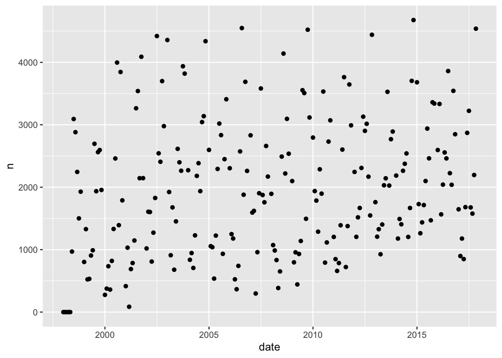

```r
fires_des <- as.data.frame(rbind(winter,spring,summer,autumn))
fires_des$index <- as.numeric(row.names(fires_des))

fires_des %>%
  count(date, wt = V7) %>%
  ggplot(aes(x = date, y = n)) +
  geom_point()
```

Now we model the deseasoned data to enable forecasting. We begin with a linear model, called fitA:

```r
fitA <- lm(fires_des$fires ~ fires_des$index)
summary(fitA)
```

```
##
## Call:
## lm(formula = fires_des$fires ~ fires_des$index)
##
## Residuals:
##     Min      1Q  Median      3Q     Max
## -1815.8 -1088.5  -276.2   913.5  3702.6
##
## Coefficients:
##                 Estimate Std. Error t value Pr(>|t|)
## (Intercept)     1700.243    174.331   9.753  < 2e-16 ***
## fires_des$index    3.371      1.258   2.679  0.00795 **
## ---
## Signif. codes:  0 '***' 0.001 '**' 0.01 '*' 0.05 '.' 0.1 ' ' 1
##
## Residual standard error: 1293 on 218 degrees of freedom
## Multiple R-squared:  0.03187,    Adjusted R-squared:  0.02743
## F-statistic: 7.177 on 1 and 218 DF,  p-value: 0.007949
```

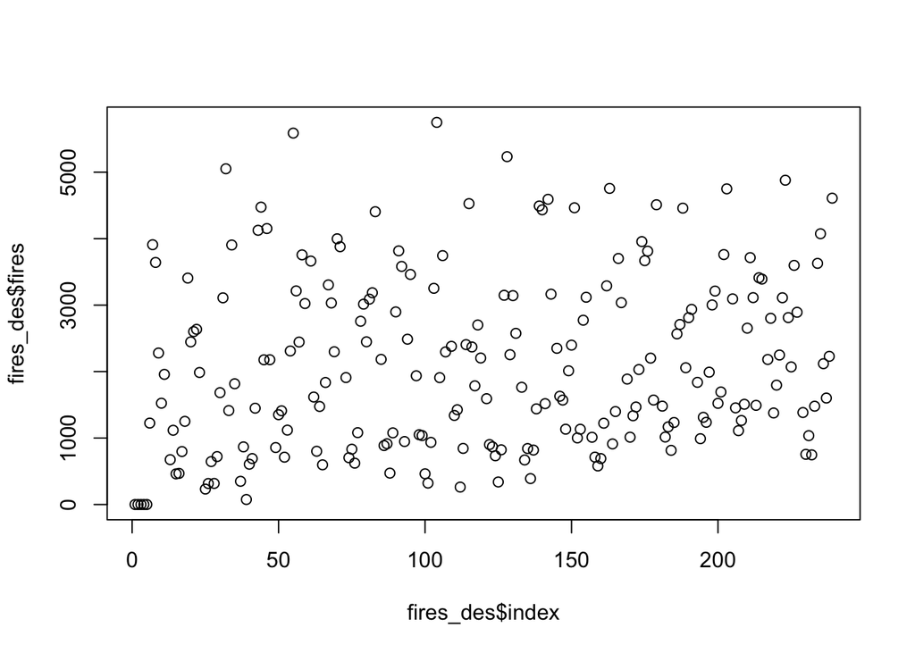

```r
plot(fires_des$index, fires_des$fires)
```

The summary statistics show significance in the p-values. However, let’s go further and find a better model. Checking the ACF and PACF plots:

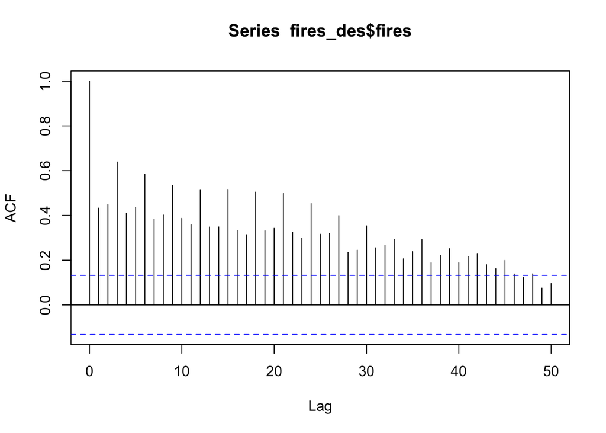

```r
library(lmtest)
acf(fires_des$fires, lag.max = 50)
```

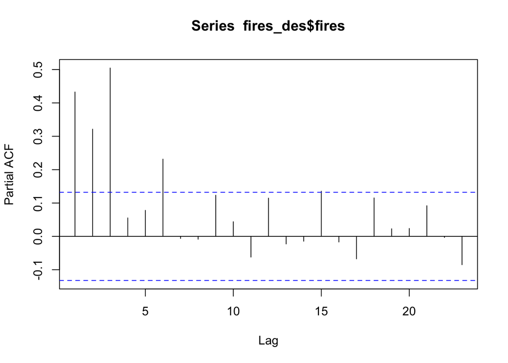

```r
pacf(fires_des$fires)
```

```r
arima101 <- arima(fires_des$fires, order = c(1,0,1))
coeftest(arima101)
```

```
##
## z test of coefficients:
##
##              Estimate  Std. Error  z value  Pr(>|z|)
## ar1        9.8985e-01  9.4727e-03 104.4953 < 2.2e-16 ***
## ma1       -8.5720e-01  3.3574e-02 -25.5320 < 2.2e-16 ***
## intercept  2.0051e+03  6.8924e+02   2.9091  0.003624 **
## ---
## Signif. codes:  0 '***' 0.001 '**' 0.01 '*' 0.05 '.' 0.1 ' ' 1
```

```r
arima202 <- arima(fires_des$fires, order = c(2,0,2))
coeftest(arima202)
```

```
##
## z test of coefficients:
##
##             Estimate Std. Error z value  Pr(>|z|)
## ar1          1.09067    0.22323  4.8858 1.030e-06 ***
## ar2         -0.10492    0.22099 -0.4748  0.634944
## ma1         -1.11848    0.20859 -5.3621 8.228e-08 ***
## ma2          0.29027    0.18014  1.6114  0.107099
## intercept 1976.55544  635.98504  3.1079  0.001884 **
## ---
## Signif. codes:  0 '***' 0.001 '**' 0.01 '*' 0.05 '.' 0.1 ' ' 1
```

The ARIMA(1,0,1) model seems significant but not the ARIMA(2,0,2). We implement differencing into our model:

```r
arima111 <- arima(fires_des$fires, order = c(1,1,1))
coeftest(arima111)
```

```
##
## z test of coefficients:
##
##      Estimate Std. Error  z value Pr(>|z|)
## ar1 -0.176708   0.076624  -2.3062   0.0211 *
## ma1 -0.817890   0.044377 -18.4307   <2e-16 ***
## ---
## Signif. codes:  0 '***' 0.001 '**' 0.01 '*' 0.05 '.' 0.1 ' ' 1
```

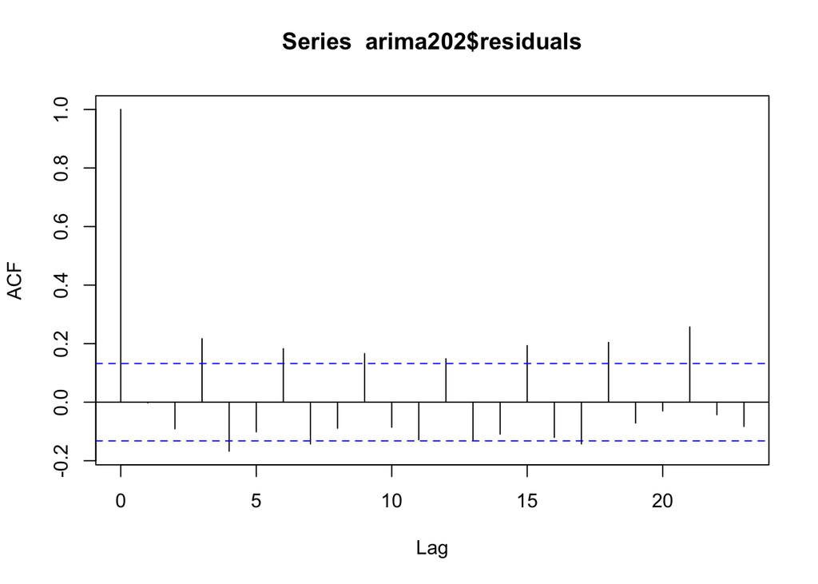

```r
acf(arima202$residuals)
```

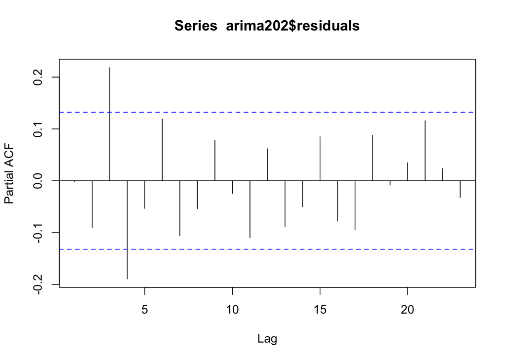

```r
pacf(arima202$residuals)
```

```r
arima212 <- arima(fires_des$fires, order = c(2,1,2))
coeftest(arima212)
```

```
##
## z test of coefficients:
##
##      Estimate Std. Error z value  Pr(>|z|)
## ar1 -0.736739   0.123223 -5.9789 2.246e-09 ***
## ar2 -0.388919   0.078585 -4.9490 7.459e-07 ***
## ma1 -0.246865   0.125298 -1.9702   0.04881 *
## ma2 -0.312528   0.116271 -2.6879   0.00719 **
## ---
## Signif. codes:  0 '***' 0.001 '**' 0.01 '*' 0.05 '.' 0.1 ' ' 1
```

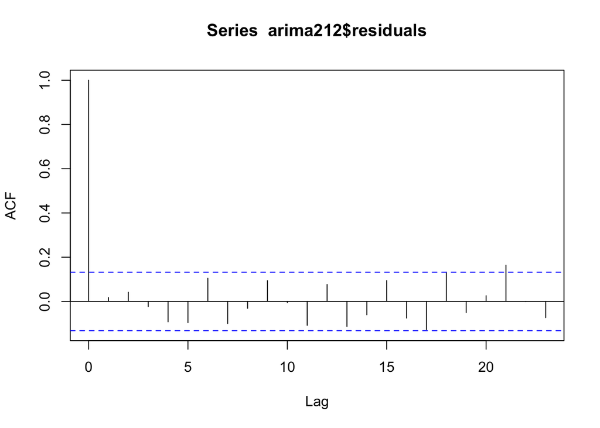

```r
acf(arima212$residuals)
```

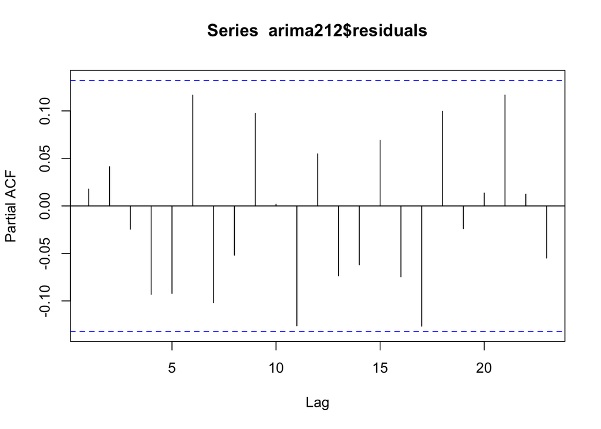

```r
pacf(arima212$residuals)
```

Now the coeftest shows significance and our PACF plot seems perfect! However the ACF plot suggests we need more MA:

```r
arima213 <- arima(fires_des$fires, order = c(2,1,3))
coeftest(arima213)
```

```
##
## z test of coefficients:
##
##      Estimate Std. Error  z value Pr(>|z|)
## ar1 -0.969974   0.030083 -32.2436  < 2e-16 ***
## ar2 -0.966814   0.024951 -38.7481  < 2e-16 ***
## ma1  0.045904   0.068188   0.6732  0.50082
## ma2  0.158330   0.064658   2.4487  0.01434 *
## ma3 -0.682569   0.058737 -11.6208  < 2e-16 ***
## ---
## Signif. codes:  0 '***' 0.001 '**' 0.01 '*' 0.05 '.' 0.1 ' ' 1
```

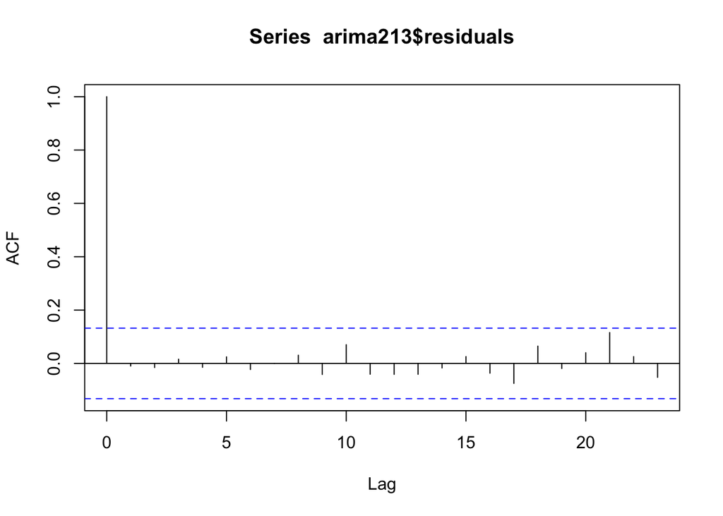

```r
acf(arima213$residuals)
```

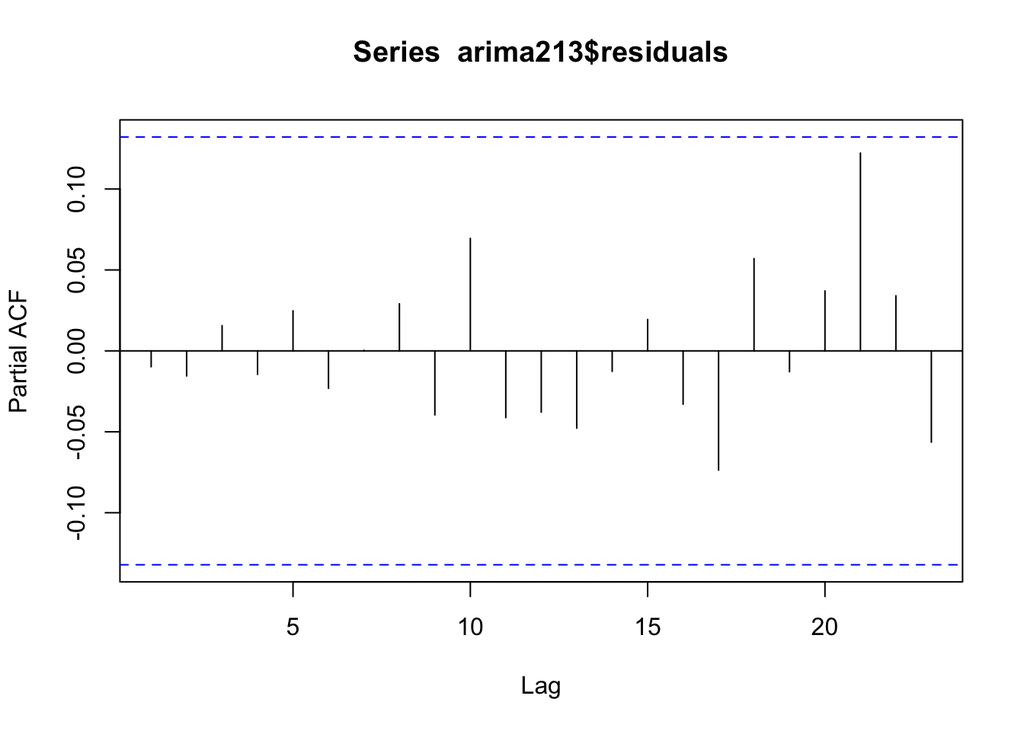

```r
pacf(arima213$residuals)
```

```r
fit_B <- arima213
```

##Forecasting Using out two models (fitA and fitB), the fires count for December 2017 has been forecasted:

```r
prediction_A <- (1700.243 + 3.371*240)*m_alt[1]
prediction_A
```

```
## [1] 2109.442
```

```r
prediction_B <- forecast(fit_B, h = 1)
prediction_B
```

```
##     Point Forecast    Lo 80    Hi 80    Lo 95    Hi 95
## 221       1915.295 785.3757 3045.213 187.2328 3643.356
```

###Random component Now the random term can be examined in closer detail.

```r
fires_decomp <- fires_all %>%
  classical_decomposition() %>%
  na.omit()
```

```
## Model not specified, defaulting to automatic modelling of the `fires` variable. Override this using the model formula.
```

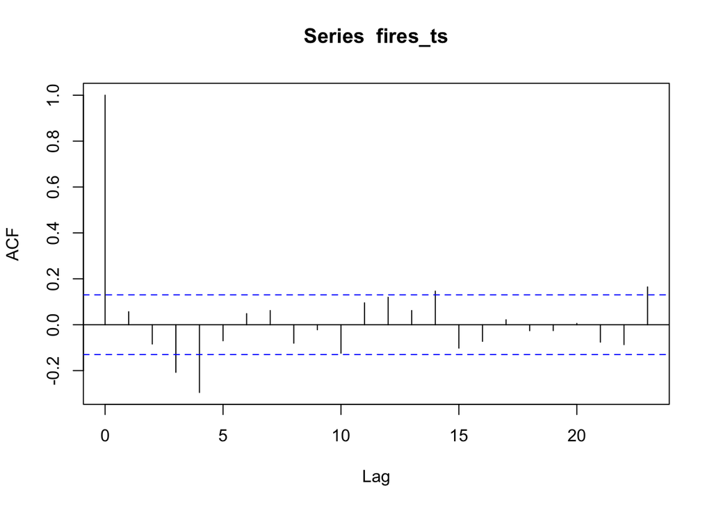

```r
fires_ts <- ts(fires_decomp$random)
acf(fires_ts)
```

The ACF of this data shows an alternating ACF, following what appears to follow a wave form shape. This shape has some peaks (both positive and negative), for a high number of lags (see 3, 4, 14, 23). It would be interesting to see this with an increased number of lags:

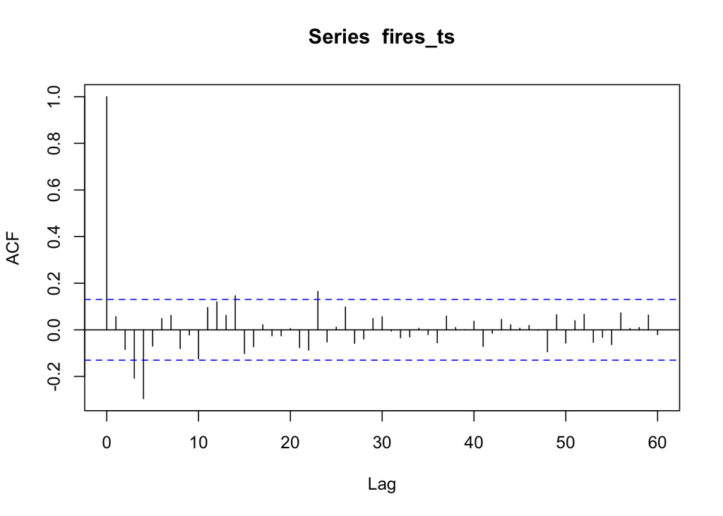

```r
acf(fires_ts, lag.max = 60)
```

After displaying the ACF for up to 60 lags, it seems that this alternating wave pattern continues, but 23 is the last lag that has any significant influence.

Now observing the PACF.

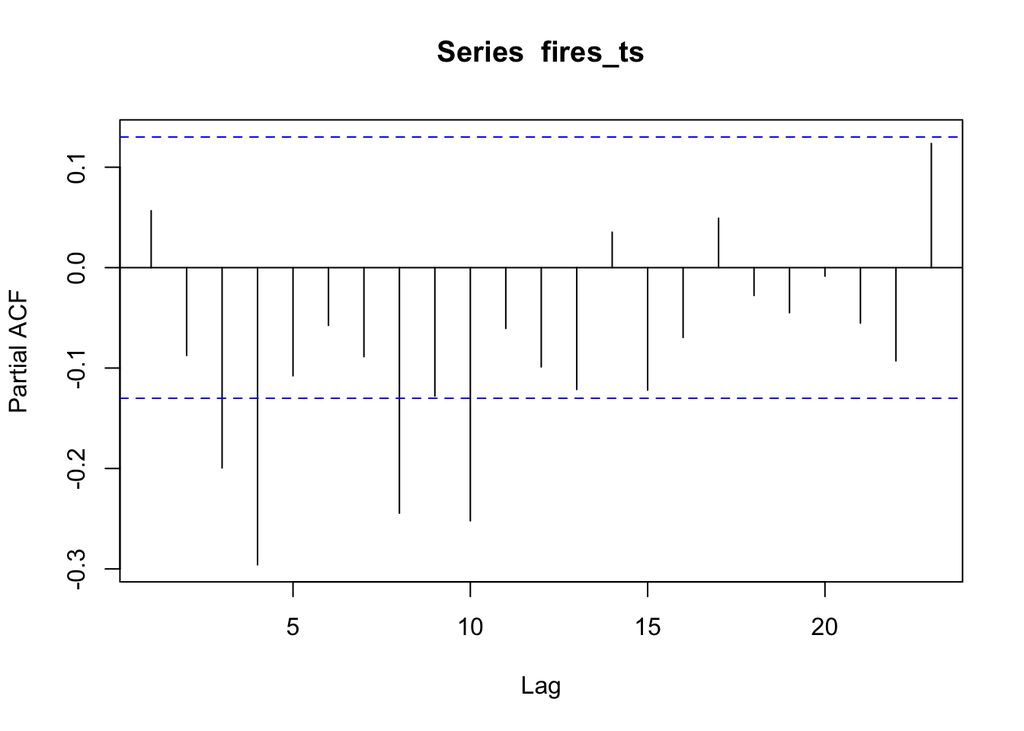

```r
pacf(fires_ts)
```

The PACF funciton for this time series shows some significant lags at 3, 4, 8, 10 etc. This should be examined in the same way as the ACF (through viewing a larger number of lags):

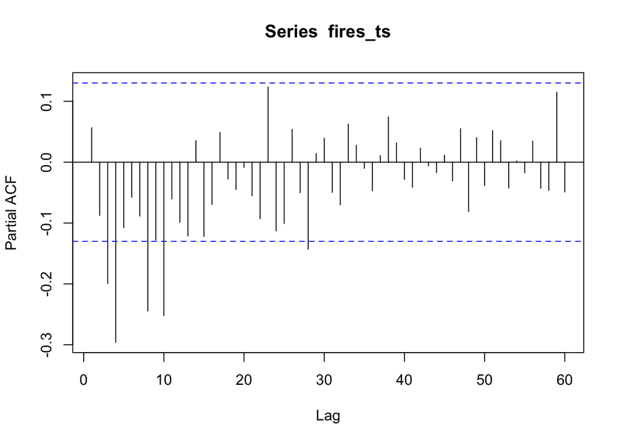

```r
pacf(fires_ts, lag.max = 60)
```

The lags mentioned above seem to be the most influential, however, these spikes can be seen in the later lags as well. The overall pattern shows a diminishing alternating effect that trends towards an exaggerated version of the ACF function.

The results after looking at the ACF and PACF do not immediately point to a specific model, as there is a large number of lags that are influential and there seems to be something of a cyclic or seasonal effect in fucntion values.

##Modelling the Aggregate Time Series Noting that there is not a model that is immediately obvious after observing both the PACF and ACF, the decomposed data will be modelled using a general framework. The `fable` framework, allows modelling on time series to be done while optimising the accuracy of results. This is done by allowing the values of the specified models to vary over a set range (for ARIMA it is generally 1:6). The best model is then selected.

```r
fires_decomp_models <- fires_decomp %>%
  rename(fires_original = fires, fires_var = random) %>%
  as_tsibble() %>%
  model(
    arima = ARIMA(fires_var),
    snaive = SNAIVE(fires_var)
  )
```

```
## Using `date` as index variable.
```

```r
fires_decomp_models$arima
```

```
## [1] ARIMA(2,0,0)(0,0,1)[12]
```

This creates a seasonal ARIMA model with parameters (2, 0, 0) (0, 0, 1).

A seasonal ARIMA model is formed by including additional seasonal terms in the ARIMA models:

$ARIMA\ (p,d,q)\ (P,D,Q)_m$

where $(p,d,q)$ and $(P,D,Q)_m$ denotes the non-seasonal part and the seasonal part of the model, respectively. $m$ denotes the number of observations per year.

The seasonal part of the model consists of terms that are similar to the non-seasonal components of the model, but involves backshifts of the seasonal period. The seasonal part of an AR or MA model will be seen in the seasonal lags of the PACF and ACF. For example, an $ARIMA\ (0,0,0)\ (0,0,1)_12$ model will show:

- a spike at lag 12 in the ACF but no other significant spikes;
- exponential decay in the seasonal lags of the PACF (that is, at lags 12, 24, 36, …).

Similarly, an $ARIMA\ (0,0,0)\ (1,0,0)_12$ model will show:

- exponential decay in the seasonal lags of the ACF;
- a single significant spike at lag 12 in the PACF.

##Forecasting

```r
fires_decomp_forecast <- fires_decomp_models %>%
  fabletools::forecast(h = "2 years")
```

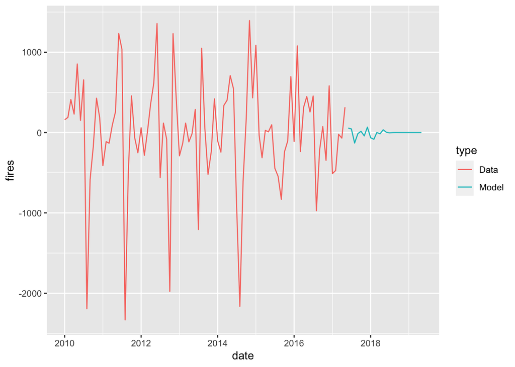

```r
forecast_clean <- fires_decomp_forecast %>%
  filter(.model == "arima") %>%
  as_tibble() %>%
  select(date, fires = fires_var) %>%
  mutate(type = "Model")


fires_decomp %>%
  select(- fires) %>%
  select(date, fires = random) %>%
  filter(date >= lubridate::ymd("20100101")) %>%
  mutate(type = "Data") %>%
  bind_rows(forecast_clean) %>%
  ggplot(aes(x = date,  y = fires, colour = type)) +
  geom_line()
```

It can be seen that this model trends towards 0 and has little variation comparatively to the original data.

##Modelling Original Data * Fable can model the data and automatically add back in seasonality and trend, resulting in a wholistic forecasting model.

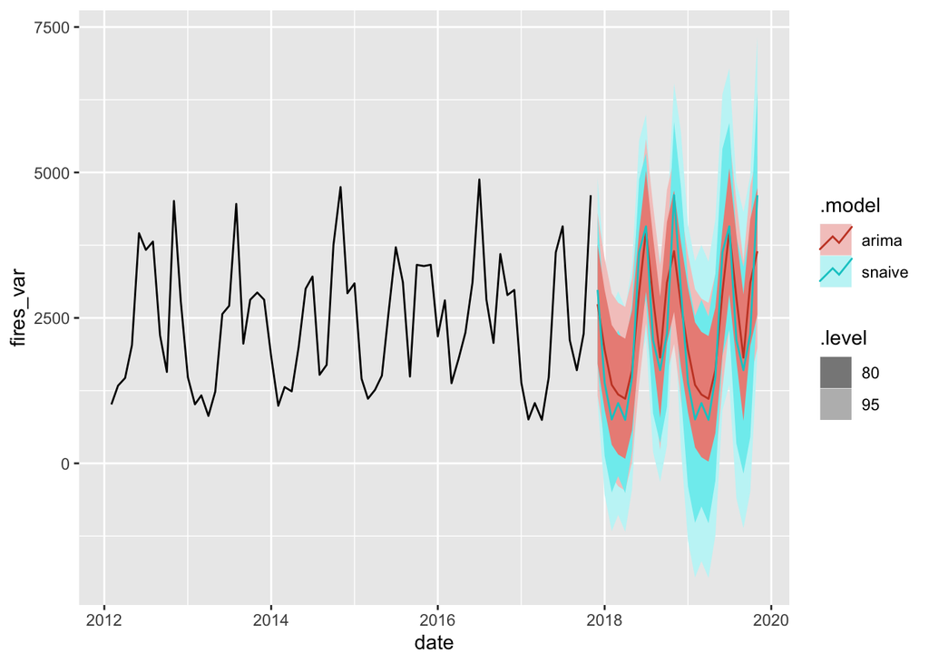

```r
fire_models <- fires_all %>%
  rename(fires_var = fires) %>%
  model(
    arima = ARIMA(fires_var),
    snaive = SNAIVE(fires_var)
  )

forecast_2 <- fire_models %>%
  fabletools::forecast(h = "2 years")

forecast_5 <- fire_models %>%
  fabletools::forecast(h = "5 years")

forecast_2 %>%
  autoplot(filter(rename(fires_all, fires_var = fires), date > lubridate::ymd("2012-01-01")))
```

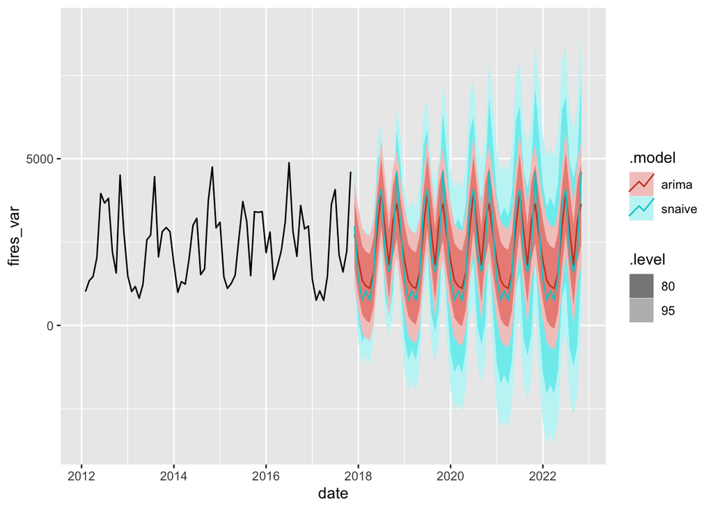

```r
forecast_5 %>%
  autoplot(filter(rename(fires_all, fires_var = fires), date > lubridate::ymd("2012-01-01")))
```

It can be seen that the arima and snaive models stay relatively close together, though the (prediction I think????) interval for arima seems to be constant with time whereas the snaive model is increasing with time.

## Model Validation and Testing

- Use data up until a certain point to use as training data.

Frist lets have a look at the time range for the fires data.

```r
fires_all %>%
  pull(date) %>%
  range()
```

```
## [1] "1998 Jan" "2017 Nov"
```

It goes from January of 1998 to November of 2017. In the previous examples, 2 years were forecast in order to look at the modelling process. This same amount of time will be forecast to assess the models.

Before assessing the models, the training data needs to be obtained by filtering anything after November 2015.

```r
fires_train <- fires_all %>%
  filter(date <= lubridate::ymd("2015-11-01"))

fires_test <- fires_all %>%
  filter(date > lubridate::ymd("2015-11-01"))
```

The models will be trained on this data.

```r
train_models <- fires_train %>%
  rename(fires_var = fires) %>%
  model(
    arima = ARIMA(fires_var),
    snaive = SNAIVE(fires_var)
  )
```

The remaining data will now be forecast for. The predicted data will be stored in a results object, which will be compared against the gruondtruth to obtain an accuracy metric.

```r
forecast_data <- train_models %>%
  fabletools::forecast(h = "2 years")
arima_prediction <- forecast_data %>%
  filter(.model == "arima")

snaive_prediction <- forecast_data %>%
  filter(.model == "snaive")
```

```r
arima_mse <- mean((fires_test$fires - arima_prediction$fires_var)^2)
snaive_mse <- mean((fires_test$fires - snaive_prediction$fires_var)^2)
glue::glue("The mean squared error of ARIMA is:  {arima_mse}
           The mean squared error of SNAIVE is: {snaive_mse}")
```

```
## The mean squared error of ARIMA is:  502092.248833118
## The mean squared error of SNAIVE is: 613217.855245167
```

#References

https://otexts.com/fpp2/seasonal-arima.html